# Module 7 - Regression Discontinuity (Answer Key)

ECON 526/593E

# Regression Discontinuity

*Rank-Based Groupings and Decision Making: A Regression Discontinuity Analysis of the NFL Draft Rounds and Rookie Compensation* by Quinn Keefer

**Click for Submission Instructions & Data**

Prepare your answers in R Markdown. Your submission should contain the exact same headings shown below along with your text and graphs, where appropriate, addressing all questions. When you knit your R Markdown script, use the following file naming convention for the html and Rmd documents you generate: lastname_module_N_homework.html (.Rmd) (replace "lastname" with your last name and "N" with the module number). Email your documents as attachments to ajc0056@mix.wvu.edu with the subject line "ECON 593 lastname Homework Module N". You can download the data for this module here. It will specify when/where packages are needed.

Regression Discontinuity Design (RDD) is a relatively old causal inference method that only recently became common is economics. RDD requires two key features to implement: a continuous assignment variable, called "the running variable" and some clear, exogenous threshold value or cutoff of the running variable that delineates treated units from control units. It resembles a Dif-in-Dif where the "difference" switch depends on the cutoff value, not on some arbitrary point in time when the treatment switch gets flipped. But RDD does not require panel data.

Since test scores represent a viable running variable that often contains clear threshold values, it is not surprising that RDD first emerged in educational research. The first paper to use RDD, Thistlewaite and Campbell (1960) analyzed scores on the CEEB Scholarship Qualifying Test (SQT) for the National Merit Scholarship program. Test takers had to score 11 or higher on the SQT to qualify for a "Certificate of Merit" in the program.

RDD can be applied in many settings outside education. This homework uses an example from the sports/labor literature based on the National Football League draft. The order in which football players were drafted constitutes the running variable in this example, and the arbitrary cutoffs for rounds (first round, second round) represent the threshold values.

## Question 1

Summarize the main research question in the paper, the application analyzed and why RDD is appropriate for this research question. (**2 Points**)

## Question 2

Read in the dataset and name it `nfl`. Only keep the columns `"season", "team", "real_capvalue", "g", "gs", "draft_round", "draft_pkoverall"`. Create a vector (call it `lim`) that identifies players picked in the first, second or third rounds in the 2011 through 2017 seasons. Scale the salary variable (`real_capvalue`) by $1,000 for simplicity.

Using `stargazer`, generate summary statistics for only these observations. Generate a similar table to Table 1 in the paper (hint[^1]). (**2 points**)

```r
#nfl <- read.csv("C:/Users/alexc/Dropbox/AlexCardazziResearch/ECON526/homeworks/module#7/nfl_draft_data.csv")

nfl <- read.csv("nfl_draft_data.csv")

nfl <- nfl[,c("season", "team", "real_capvalue", "g", "gs", "draft_round", "draft_pkoverall")]
lim <- nfl$season %in% 2011:2017 & nfl$draft_round %in% 1:3
nfl$real_capvalue <- nfl$real_capvalue / 1000

library("stargazer")
stargazer(nfl[lim,], type = "text")
```

```
##
## ==========================================================================
## Statistic        N    Mean    St. Dev.  Min   Pctl(25) Pctl(75)     Max
## --------------------------------------------------------------------------
## season          686 2,014.085  2.000   2,011   2,012     2,016     2,017
## real_capvalue   686 1,239.880 946.762  48.985 629.698  1,576.773 5,529.501
## g               686  12.093    4.892     0       10       16        16
## gs              686   6.402    5.949     0       0        12        16
## draft_round     686   2.036    0.827     1       1         3         3
## draft_pkoverall 686  50.098    28.776    1       25       75        107
## --------------------------------------------------------------------------
```

```r
agg <- aggregate(nfl$real_capvalue[lim]/1000, list(nfl$season[lim], nfl$draft_round[lim]), mean)
agg$x <- round(agg$x, 1)
t(cbind(agg$Group.1[agg$Group.2 == 1],
        agg$x[agg$Group.2 == 1],
        agg$x[agg$Group.2 == 2],
        agg$x[agg$Group.2 == 3])) -> agg
colnames(agg) <- agg[1,]
agg <- agg[-1,]
row.names(agg) <- c("Round 1", "Round 2", "Round 3")
cat("Mean Compensation by Round and Year:\n\n")
agg
```

```
## Mean Compensation by Round and Year:
##
##         2011 2012 2013 2014 2015 2016 2017
## Round 1  2.1  2.1  2.1  2.1  2.4  2.6  2.7
## Round 2  0.8  0.8  0.8  0.8  0.9  1.0  1.0
## Round 3  0.6  0.6  0.6  0.6  0.6  0.6  0.7
```

## Question 3

Describe the causal inference method used in the Keefer paper. Discuss the assumptions underlying the causal inference method used in the empirical analysis. Include a discussion of threats to validity of the results in terms of causal inference. (**2 points**)

## Question 4

Visualize the data. Generate two side by side plots. In the first plot, show the average compensation by draft pick (`draft_pkoverall`) for the first and second rounds. In the second plot, do the same thing but for the second and third rounds. Draw vertical lines at 32.5 and 64.5, which identify breaks in between rounds. Generate another two side by side, but instead use the number of games started (hint[^2]). Make all of these nice colors and shapes and make sure to label your axes! When you are done, make sure to reset your plotting parameters such that you are no longer plotting side by side. What can we learn from these plots? (**2 points**)

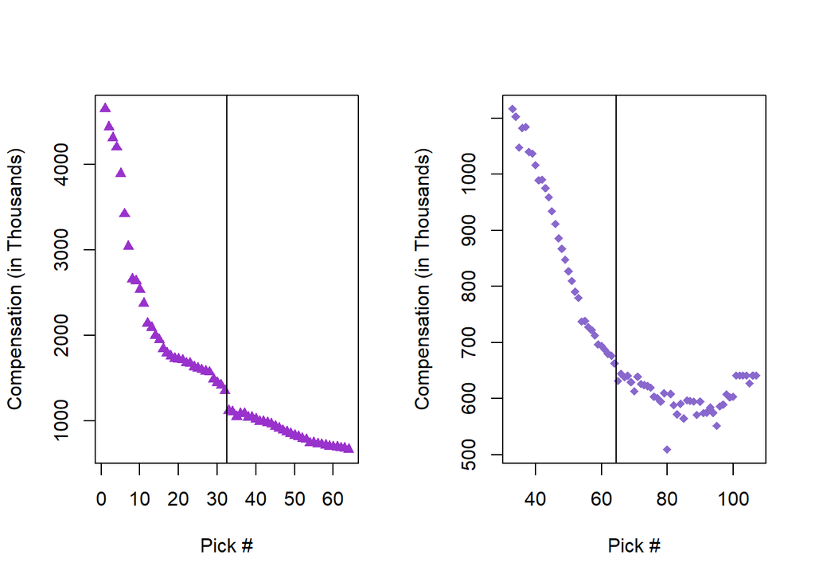

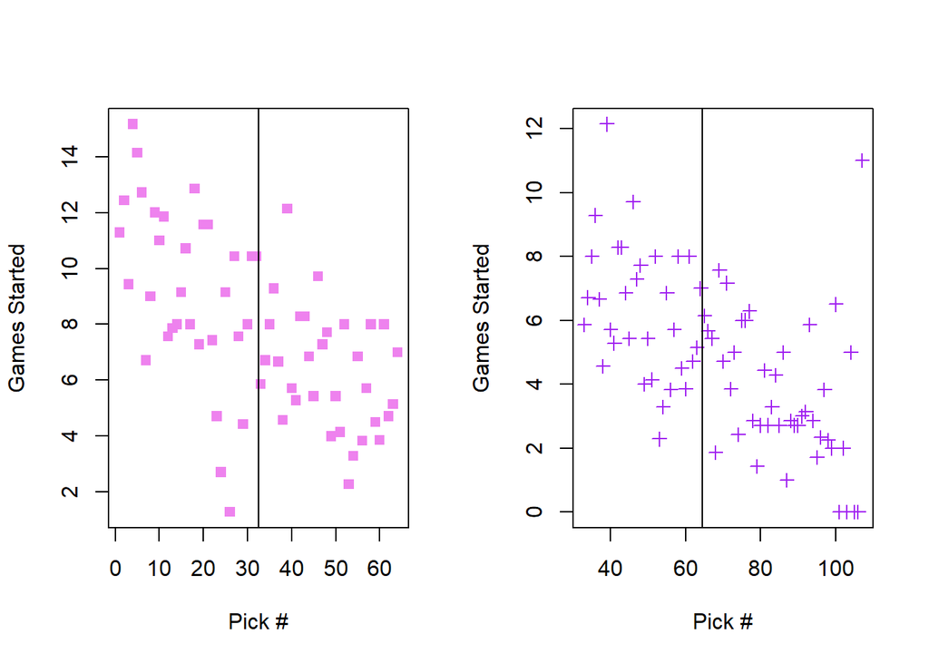

```r
par(mfrow = c(1,2))
agg <- aggregate(nfl$real_capvalue[lim], list(nfl$draft_pkoverall[lim]), mean)
lim2 <- agg$Group.1 < 65
plot(agg$Group.1[lim2], agg$x[lim2], xlab = "Pick #", ylab = "Compensation (in Thousands)",
     col = "darkorchid", pch = 17)
abline(v = 32.5)

lim2 <- agg$Group.1 > 32
plot(agg$Group.1[lim2], agg$x[lim2], xlab = "Pick #", ylab = "Compensation (in Thousands)",
     col = "mediumpurple3", pch = 18)
abline(v = 64.5)

## GS ####

agg <- aggregate(nfl$gs[lim], list(nfl$draft_pkoverall[lim]), mean)
lim2 <- agg$Group.1 < 65
plot(agg$Group.1[lim2], agg$x[lim2], xlab = "Pick #", ylab = "Games Started",
     col = "violet", pch = 15)
abline(v = 32.5)

lim2 <- agg$Group.1 > 32
plot(agg$Group.1[lim2], agg$x[lim2], xlab = "Pick #", ylab = "Games Started",
     col = "purple", pch = 3)
abline(v = 64.5)

par(mfrow = c(1,1))
```

## Question 5

Replicate the main results in the Keefer paper to see if the effect has remained in the NFL over the 2011-2017 period compared to the earlier time period studied by Keefer.

Install and load the `rdd` package. Focus your analysis on two rounds at a time (hint[^3]). In other words, test for a discontinuity in salary between rounds 1 and 2, and then again between rounds 2 and 3. Save a new variable `season_I` that is the factor version of `season`. From the `rdd` package, use the `RDestimate` function (hint[^4]). In addition, you do *not* need to specify a bandwidth!) to generate results like those reported on on Table 5 in the Keefer paper (but not actual results in the paper).

For the first regression model, use only observations for the first and second rounds. Make the cutoff equal to 32.5. Control for both `season_I` and `team` (hint[^5]). Replicate this for the second and third rounds. Use the `summary` function to display the results. (**2 points**)

```r
# install.packages("rdd")
library("rdd")

nfl$season_I <- as.factor(nfl$season)
```

```r
cat("##### MODEL 1 #####\n\n\n")
lim1 <- lim & nfl$draft_round %in% 1:2
rdd1 <- RDestimate(real_capvalue ~ draft_pkoverall | season_I + team, data = nfl[lim1,], cutpoint = 32.5)
summary(rdd1)
cat("\n\n\n##### MODEL 2 #####\n\n\n")
lim2 <- lim & nfl$draft_round %in% 2:3
rdd2 <- RDestimate(real_capvalue ~ draft_pkoverall | season_I + team, data = nfl[lim2,], cutpoint = 64.5)
summary(rdd2)
```

```
## ##### MODEL 1 #####
##
##
##
## Call:
## RDestimate(formula = real_capvalue ~ draft_pkoverall | season_I +
##     team, data = nfl[lim1, ], cutpoint = 32.5)
##
## Type:
## sharp
##
## Estimates:
##            Bandwidth  Observations  Estimate  Std. Error  z value  Pr(>|z|)
## LATE       10.678     152           -245.0    28.30        -8.656  4.901e-18  ***
## Half-BW     5.339      68           -231.7    26.88        -8.621  6.631e-18  ***
## Double-BW  21.355     292           -256.6    20.06       -12.791  1.847e-37  ***
## ---
## Signif. codes:  0 '***' 0.001 '**' 0.01 '*' 0.05 '.' 0.1 ' ' 1
##
## F-statistics:
##            F       Num. DoF  Denom. DoF  p
## LATE        62.92  41        110         0.000e+00
## Half-BW     10.73  38         29         3.701e-09
## Double-BW  223.91  42        249         0.000e+00
##
##
##
## ##### MODEL 2 #####
##
##
##
## Call:
## RDestimate(formula = real_capvalue ~ draft_pkoverall | season_I +
##     team, data = nfl[lim2, ], cutpoint = 64.5)
##
## Type:
## sharp
##
## Estimates:
##            Bandwidth  Observations  Estimate  Std. Error  z value   Pr(>|z|)
## LATE        9.683     136           -21.4113  6.402       -3.34454  8.242e-04  ***
## Half-BW     4.841      69           -34.6215  8.094       -4.27765  1.889e-05  ***
## Double-BW  19.366     262            -0.4966  7.185       -0.06912  9.449e-01
## ---
## Signif. codes:  0 '***' 0.001 '**' 0.01 '*' 0.05 '.' 0.1 ' ' 1
##
## F-statistics:
##            F      Num. DoF  Denom. DoF  p
## LATE       37.01  42         93         0
## Half-BW    46.05  38         30         0
## Double-BW  37.44  42        219         0
```

**BONUS** RDD estimates are very dependent on the choice of bandwidth. Often times, economists will rerun their RDD for a bunch of different bandwidths to see how sensitive the results are to this choice. Rerun the models with every bandwidth from 5 to 15 with an increment of .5. Use `seq(5, 15, .5)` to help you. Plot the coefficient estimates with their 95% confidence intervals. Draw a vertical line where the bandwidth of the previous models were located.

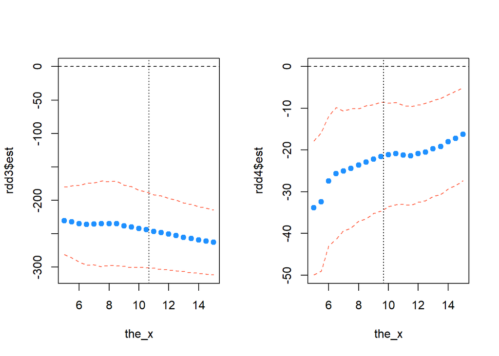

```r
the_x <- seq(5, 15, .5)
par(mfrow = c(1,2))

rdd3 <- RDestimate(real_capvalue ~ draft_pkoverall | season_I + team,
                   data = nfl[lim1,],
                   cutpoint = 32.5, bw = the_x)

plot(the_x, rdd3$est,
     pch = 19, col = "dodgerblue",
     ylim = c(min(c(0, rdd3$est - 1.96*rdd3$se)),
              max(c(0, rdd3$est + 1.96*rdd3$se))))
lines(the_x, rdd3$est + 1.96*rdd3$se, col = "tomato", lty = 2)
lines(the_x, rdd3$est - 1.96*rdd3$se, col = "tomato", lty = 2)
abline(h = 0, lty = 2)
abline(v = rdd1$bw[1], lty = 3)

rdd4 <- RDestimate(real_capvalue ~ draft_pkoverall | season_I + team,
                   data = nfl[lim2,], cutpoint = 64.5,
                   bw = the_x)

plot(the_x, rdd4$est,
     pch = 19, col = "dodgerblue",
     ylim = c(min(c(0, rdd4$est - 1.96*rdd4$se)),
              max(c(0, rdd4$est + 1.96*rdd4$se))))
lines(the_x, rdd4$est + 1.96*rdd4$se, col = "tomato", lty = 2)
lines(the_x, rdd4$est - 1.96*rdd4$se, col = "tomato", lty = 2)
abline(h = 0, lty = 2)
abline(v = rdd2$bw[1], lty = 3)
```

## Question 6

Discuss the results you generated. What is the interpretation of the causal parameter of interest? Place the causal effect in the context of the data. Compare your results to those reported in the Keefer NFL draft paper. (**2 points**)

## Question 7

Compare your results and this application to the example in the Mixtape chapter for this causal inference method [Hoekstra, Mark. 2009. “The Effect of Attending the Flagship State University on Earnings: A Discontinuity-Based Approach.” Review of Economics and Statistics 91 (4): 717–24]. Is this application better or worse than the one in the chapter? How does this application, and these results, differ? For example, strength of assumptions, effect size, etc. (**2 points**)

## Question 8

Do you believe the results you generated are credibly causal? Are the sign and magnitude plausible? (**2 points**)

[^1]: This will take some effort. You will need to use the aggregate function, and then manipulate this. Think about how you might use [`cbind()`, `rbind()`](https://bookdown.org/ndphillips/YaRrr/creating-matrices-and-dataframes.html#cbind-rbind), [`t()`](https://www.dataanalytics.org.uk/rotating-or-transposing-r-objects/). You do *not* need packages to acheive this.
[^2]: Use the aggregate function to help you. Make sure to only use the limited data! Make a second vector (call it `lim1`) that selects the draft picks you are interested in i.e. `< 65` or `> 32`
[^3]: Use ANOTHER vector to limit/subset the data for analysis. Call this whatever you want, you're a pro by now!
[^4]: [Resource 1](https://www.jepusto.com/rdd-interactions/), [Resource 2](https://cran.r-project.org/web/packages/rdd/rdd.pdf)
[^5]: To control for things in `RDestimate`, it is a bit different. Make sure to read the documentation! Bottom of [this](https://cran.r-project.org/web/packages/rdd/rdd.pdf#page=7) page.